# TRATAMIENTO DE DATOS CON R

Joaquín Planelles Romero e Isabel Padilla Sánchez

octubre de 2021

# tidyr

[figure not shown]

La librería tidyr incorpora un conjunto de funciones que te ayudan a organizar/ordenar tus datos. Ya hemos hablado con anterioridad de los datos tidyr o ‘datos ordenados’. Resumiendo, los datos estarán ordenados cuando cada columna es una única variable.

La librería `tidyr` nos va a facilitar varias cosas: (1) Estructurar nuestros datos para que sean datos ordenados. Se trataría de un primer paso, previo al trabajo con otras librerías de tidyverse como `dplyr`, sacando así el mayor provecho a la eficiencia de R para trabajar con vectores. (2) Una vez hechas las transformaciones oportunas a nuestro conjunto de datos, nos puede interesar estructurar los datos por filas y columnas de otro modo, pues muchas veces de cara a la difusión de los resultados sí nos interesará tener una misma variable dividida en varias columnas. Por ejemplo, nos puede interesar generar una columna para hombres y otra columna para mujeres, que en realidad son categorías de la variable ‘sexo’. O una columna para cada provincia andaluza, etc.

Para ello, hablaremos de las funciones ‘pivot’, que son las principales funciones de tidyr. La función `pivot_longer` nos va a permitir pasar varias columnas a una única variable. La función `pivot_wider` nos permite pasar cada categoría de una variable a sendas columnas en un nuevo data.frame/tibble.

Como veremos, tidyr también tiene implementadas otras funciones de uso menos extendido, pero que en nuestra experiencia han resultado muy útiles para resolver ciertos ‘problemas’ típicos del trabajo en producción estadística. Por ejemplo, podemos usar la función `separate` para cortar ficheros planos. También podemos usar la función `expand` para generar el producto cartesiano (todas las combinaciones posibles) de dos variables categóricas.

# Las funciones ‘pivot’

En este apartado hablaremos de las funciones `pivot_longer` y `pivot_wider`. Se trata de las dos funciones principales de la librería tidyr.

Si ya habías trabajado anteriormente con la librería `tidyr` te puede resultar chocante esta terminología. Esta denominación se introdujo con la versión 1.0.0 de tidyr, a finales de 2019. Con anterioridad a esa fecha se utilizaban dos comandos con funcionalidades similares denominadas `gather` y `spread`. Si llamas a las antiguas funciones, o tienes un programa que utiliza esos comandos… ¡no te preocupes! tidyr las seguirá entendiendo. Eso sí, las funciones `gather` y `spread` se quedarán tal y como eran a finales de 2019, sin las mejoras que han incorporado ya o que vayan incorporando en el futuro las nuevas funciones (no todo ha sido optar por un nombre más intuitivo).

Para ilustrar este apartado vamos a crear un data.frame con datos de la población de varias provincias andaluzas en los años 1920 y 2020. Así, de paso, refrescamos cómo crear un data.frame directamente desde R:

```r
Pob_Andal <- data.frame(Provincia = c('Granada','Jaén','Málaga','Sevilla'),
                        Pob_1920  = c(573682, 474490, 511989, 555256),
                        Pob_2020  = c(925831, 627355,1685874,1959975))
```

El resultado queda almacenado en el objeto Pob_Andal:

```
##   Provincia Pob_1920 Pob_2020
## 1   Granada   573682   925831
## 2      Jaén   474490   627355
## 3    Málaga   511989  1685874
## 4   Sevilla   555256  1959975
```

### 1. Función `pivot_longer`

La función `pivot_longer` nos va a permitir colapsar varias columnas en una única variable. Las columnas que teníamos en el data.frame original pasarán a ser categorías de una única columna en el nuevo data.frame. Nuestro nuevo conjunto de datos va a seguir siendo rectangular, claro, pero va a tener más filas que antes y menos columnas. De ahí lo de “longer”. Cada columna del data.frame original dará lugar a una categoría de la nueva variable. Ilustrémoslo con nuestro ejemplo. Pasemos las columnas ‘Pob_1920’ y ‘Pob_2020’ a una única variable a la que llamaremos ‘Periodo’.

Os recomendamos que le dediquéis un ratito a mirar en la chuleta los distintos argumentos que se pueden usar con la función. En nuestro ejemplo, hemos utilizado 4 argumentos. Los tres primeros son los argumentos obligatorios, el último es un argumento opcional, de los muchos que admite la función:

1. Con el argumento `cols=c(...)` indicamos qué columnas vamos a unificar en una única variable
2. Con el argumento `names_to='...'` damos nombre a la nueva variable
3. Con el argumento `values_to='...'` damos nombre a la medida.
4. Con el argumento `names_prefix='...'` indicamos que no queremos utilizar el prefijo ‘Pob_’ que contienen los nombres de las columnas originales.

```r
Ejemplo_longer <- Pob_Andal %>% pivot_longer(cols=c(Pob_1920,Pob_2020), names_to='Periodo', values_to='Población', names_prefix='Pob_')
```

[output not shown]

### 2. Función `pivot_wider`

La función `pivot_wider` hace más o menos lo contrario: pasamos cada categoría de una variable del data.frame original a nuevas columnas en el nuevo data.frame (se crearán tantas columnas como categorías tenga la variable del data.frame original). De nuevo, obtendremos un conjunto de datos rectangular, pero con menos filas y más columnas que el original, de ahí lo de “wider”.

Para ilustrarlo, vamos a partir del data.frame `Ejemplo_longer` y vamos a hacer la transformación inversa, obteniendo una columna con los datos de cada año (1920 y 2020):

```r
Ejemplo_wider <- Ejemplo_longer %>% pivot_wider(names_from=Periodo, values_from=Población, names_prefix='Pob_')
```

```
## # A tibble: 4 x 3
##   Provincia Pob_1920 Pob_2020
##   <chr>        <dbl>    <dbl>
## 1 Granada     573682   925831
## 2 Jaén        474490   627355
## 3 Málaga      511989  1685874
## 4 Sevilla     555256  1959975
```

Nada más. Vale la pena dedicarle un rato a estudiar los argumentos que incluyen las funciones de pivotaje. Hay algunos pensados para asignar nombres a las variables/categorías. Otros para ordenarlas. Otros argumentos sirven para que indiquéis qué queréis hacer con los nulos que se generan en estas transformaciones (¿Os interesa que aparezca una fila con valores a nulo o es mejor no mostrarla? ¿los nulos los dejamos a ‘NA’ o los transformamos en ceros, o quizás en ‘No procede’?).

Como siempre que se trata de argumentos opcionales, si no indicas nada la función hará lo que tiene programado por defecto, tal y como podéis comprobar en la chuleta o, alternativamente, buscando información sobre la función en la consola: `?pivot_longer()`

# Otras funciones de tidyr

En esta sección vamos a hacer referencia a otras funciones de `tidyr` de uso menos extendido, pero que pueden ser muy útiles en ciertos contextos. En concreto, vamos a hacer referencia a las funciones `separate` y `expand`.

Para ello, vamos a utilizar otro conjunto de datos. Se trata de un fichero plano procedente de la publiación “Un siglo de demografía en Andalucía”, ubicado en la siguiente dirección de la web del IECA: http://www.ieca.junta-andalucia.es/sid/bancoDeDatos/index.htm

Accedemos a la primera tabla de la publicación, que contiene información sobre la población andaluza en el año 1900, distinguiendo provincia de residencia, sexo y edades simples (año a año). Los datos originales ya vienen separados por punto y coma, pero vamos a transformarlos un poquito, para obtener un fichero plano sin separadores, que es lo que nos interesa de cara a los ejemplos que siguen. Para descargar los datos y hacer las transformaciones oportunas, corred el siguiente código en vuestro RStudio. Deberíais obtener un data.frame de 1.854 registros y con un único campo denominado ‘CampoPlano’, de tipo carácter y de 14 dígitos de longitud, del que mostramos los seis primeros registros:

```r
Pob1900 <- read.table('https://www.juntadeandalucia.es/institutodeestadisticaycartografia/sid/bancoDeDatos/tab/pob01o.txt', skip=1, sep=';', colClasses = 'character') %>%
           mutate(CampoPlano=paste0(V1,V2,V3,V4,V5)) %>% select(CampoPlano)
```

```
##       CampoPlano
## 1 190004M0002805
## 2 190004M0015148
## 3 190004M0024774
## 4 190004M0034682
## 5 190004M0044937
## 6 190004M0054734
```

### 1. Función `separate`

La función `separate` nos va a permitir cortar un fichero plano en los distintos campos que contiene. Para ello, el argumento `sep` de la función va a ser particularmente útil, pues nos va a permitir indicar qué carácter utilizar como separador (por ejemplo, el punto y coma, o un espacio en blanco, etcétera). Alternativamente, el argumento `sep` también admite valores numéricos. En ese caso el funcionamiento es distinto y lo que va a hacer es realizar los cortes en las posiciones fijas de columna que le hayas indicado.

Veámoslo con ejemplos. Partamos del data.frame sin separadores que hemos importado de la web del IECA, ‘Pob1900’. Necesitaremos usar la función `separate` y tres argumentos:

1. Con el argumento `col=...` indicaremos cómo se llama el campo que queremos dividir. En nuestro ejemplo, el data.frame tiene un único campo, denominado ‘CampoPlano’.
2. Con el argumento `into=c(...)` le indicamos los distintos nombres de las variables que vamos a crear a partir de ‘CampoPlano’.
3. Con el argumento `sep=c(...)` le indicamos las posiciones en las que queremos realizar los cortes.

```r
Posiciones <- Pob1900 %>% separate(col=CampoPlano, into=c('Año','Prov','Sexo','Edad','Pob'), sep=c(4,6,7,10,16))
```

De este modo, hemos creado un nuevo data.frame, denominado ‘Posiciones’ que contiene los cinco campos indicados:

```
##    Año Prov Sexo Edad  Pob
## 1 1900   04    M  000 2805
## 2 1900   04    M  001 5148
## 3 1900   04    M  002 4774
## 4 1900   04    M  003 4682
## 5 1900   04    M  004 4937
## 6 1900   04    M  005 4734
```

Nótese que si disponemos (como es frecuente en nuestro trabajo) de un fichero con el diseño de registro, podemos utilizarlo dentro de la función `separate` y extraer del propio diseño de registro los vectores de los argumentos `into` y `sep`.

### 2. Función `expand`

Finalmente, vamos a hacer referencia a la función `expand` y a otras funciones relacionadas (`expand_grid` y `complete`). Estas funciones nos va a permitir crear todos los cruces posibles entre dos variables.

La función `expand_grid`, nos permite crear el producto cartesiano de dos vectores. Esto puede ser muy útil en ciertos contextos. Por ejemplo, si queremos crear un diseño de tabla fijo (que en las filas de nuestra tabla aparezcan todas combinaciones sexo - edades simples, aunque para ese cruce no haya datos asociados en nuestro data.frame). En ese caso, podemos empezar creando las ‘cabeceras’ con la función `expand_grid` y proceder después a insertarle los datos, usando el join apropiado.

```r
ProdCart <- expand_grid(X1 = c('A','B','C'),
                        X2 = c(1, 2))
```

```
## # A tibble: 6 x 2
##   X1       X2
##   <chr> <dbl>
## 1 A         1
## 2 A         2
## 3 B         1
## 4 B         2
## 5 C         1
## 6 C         2
```

La función `expand`, a secas nos va a permitir hacer algo parecido, pero partiendo de un conjunto de datos concreto. Para verlo, volvamos a nuestro ejemplo de la población andaluza del año 1900 y vamos a quedarnos con la población entre 95 y 99 años de edad en la provincia de Huelva. Si te preguntas por qué habremos escogido un colectivo tan particular, pues te lo podemos explicar: nos interesa que haya datos faltantes, como es el caso de las mujeres de 99 años, así como de los hombres de 95, 97 y 99 años de edad. De hecho, es conveniente señalar que en toda la provincia de Huelva, en el año 1900, no había nadie de 99 años de edad.

```r
Huelva9599 <- read.table('http://www.ieca.junta-andalucia.es/sid/bancoDeDatos/tab/pob01o.txt', sep=';', colClasses = 'character', header=TRUE) %>%
              filter(COD_PROV=='21' & as.numeric(EDAD)>=95 & as.numeric(EDAD)<100 & EFECTIVO!=0)
```

```
##    AÑO COD_PROV SEXO EDAD EFECTIVO
## 1 1900       21    M  095        3
## 2 1900       21    M  096        1
## 3 1900       21    M  097        1
## 4 1900       21    M  098        1
## 5 1900       21    H  096        1
## 6 1900       21    H  098        1
```

Ahora estamos en condiciones de probar la función `expand`. Como veréis, ahora aparecen todas las combinaciones existentes en nuestro data.frame (no aparecerá, por tanto la categoría ‘99’, para la que no tenemos datos en nuestro data.frame). Como hemos dicho para otras funciones, vale la pena estudiar ahora los distintos argumentos que admite la función.

```r
HuelvaExpand <- expand(Huelva9599, SEXO, EDAD)
```

```
## # A tibble: 8 x 2
##   SEXO  EDAD
##   <chr> <chr>
## 1 H     095
## 2 H     096
## 3 H     097
## 4 H     098
## 5 M     095
## 6 M     096
## 7 M     097
## 8 M     098
```

En cuanto a la función `complete`, además de incorporar los cruces de las variables en los que estés interesado (en nuestro ejemplo SEXO y EDAD), te mostrará el resto de variables y medidas. Si no le especificas otra cosa, te pondrá un nulo. ¡Ojo! que si no quieres que te ponga nulo en el resto de variables tendrás que asignarle el valor deseado, o quizás te interese incorporarlas también al producto cartesiano:

```r
HuelvaComplete <- complete(Huelva9599, SEXO, EDAD)
```

```
## # A tibble: 8 x 5
##   SEXO  EDAD  AÑO   COD_PROV EFECTIVO
##   <chr> <chr> <chr> <chr>    <chr>
## 1 H     095   <NA>  <NA>     <NA>
## 2 H     096   1900  21       1
## 3 H     097   <NA>  <NA>     <NA>
## 4 H     098   1900  21       1
## 5 M     095   1900  21       3
## 6 M     096   1900  21       1
## 7 M     097   1900  21       1
## 8 M     098   1900  21       1
```

# Preguntas de auto-evaluación

El objetivo de las siguientes preguntas es que podáis auto-evaluar si habéis adquirido los conocimientos. Encontraréis las respuestas en la pestaña de soluciones.

Para la resolución de algunos de estos ejercicios es necesario utilizar los ficheros planos del censo de 2011 que os hemos facilitado.

  data.frame df1

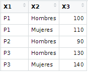

  1. df2 <- df1 %>% pivot_wider(names_from = X2, values_from=X3, values_fill=0)
  2. df2 <- df1 %>% complete(names_from = X2, values_from=X3)
  3. df2 <- df1 %>% ala_pivot(names_from = X2, values_from=X3, values_fill=0)
  4. df2 <- df1 %>% pivot_wider(names_from = X2, values_from=X3)
- **Pregunta 4**. Volvamos a los datos del Censo 2011. Con ellos, crea un nuevo data.frame, realizando las siguientes transformaciones:

  Paso 1 - Selecciona los extranjeros residentes en Jaén capital (código INE de municipio ‘23050’). Por simplificar, definimos ‘extranjeros’ como el complementario a españoles.

  Paso 2 - Agrupa por las variables sexo y edad, obteniendo el número de extranjeros para cada combinación de sexo y edad

  Paso 3 - Utiliza el comando `pivot_wider` para pasar las categorías de SEXO a columnas.

  Pregunta: ¿Cuántos registros (filas) tiene el data.frame resultante?
  1. 55
  2. 101
  3. 99
  4. 110
- **Pregunta 5**. Partamos otra vez de los datos del censo de 2011. Haz las siguientes transformaciones:

  Paso 1 - Selecciona a los nacidos en la provincia de Sevilla que son residentes en Cabra (‘14013’)

  Paso 2 - A partir de los datos del Paso 1, crea un nuevo data.frame aplicando el comando `expand` a la combinación sexo-relación con la actividad

  Paso 3 - A partir de los datos del Paso 1, crea un nuevo data.frame aplicando el comando `complete` a la combinación sexo-relación con la actividad
  1. Los data.frames obtenidos en los pasos 2 y 3 no tienen el mismo número de filas, pero sí el mismo número de columnas
  2. Los data.frames obtenidos en los pasos 2 y 3 tienen el mismo número de filas y el mismo número de columnas
  3. Los data.frames obtenidos en los pasos 2 y 3 no tienen el mismo número de filas ni el mismo número de columnas
  4. Los data.frames obtenidos en los pasos 2 y 3 tienen el mismo número de filas, pero no el mismo número de columnas

# Soluciones

A continuación se muestran, marcadas y en rojo, las soluciones a las preguntas de auto-evaluación

  data.frame df1

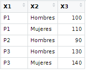

  1. **df2 <- df1 %>% pivot_wider(names_from = X2, values_from=X3, values_fill=0)**
  2. df2 <- df1 %>% complete(names_from = X2, values_from=X3)
  3. df2 <- df1 %>% ala_pivot(names_from = X2, values_from=X3, values_fill=0)
  4. df2 <- df1 %>% pivot_wider(names_from = X2, values_from=X3)
- **Pregunta 4**. Volvamos a los datos del Censo 2011. Con ellos, crea un nuevo data.frame, realizando las siguientes transformaciones:
  - Paso 1 - Selecciona los extranjeros residentes en Jaén capital (código INE de municipio ‘23050’). Por simplificar, definimos ‘extranjeros’ como el complementario a españoles.
  - Paso 2 - Agrupa por las variables sexo y edad, obteniendo el número de extranjeros para cada combinación de sexo y edad
  - Paso 3 - Utiliza el comando `pivot_wider` para pasar las categorías de SEXO a columnas.

  Pregunta: ¿Cuántos registros (filas) tiene el data.frame resultante?
  1. **55**
  2. 101
  3. 99
  4. 110

  **En concreto, hemos utilizado el siguiente código para obtener el resultado:**

  ```r
  Pregunta4 <- DATOS_HP %>% filter(CPRO=='23' & CMUN=='050' & NACI!='108') %>%
                            group_by(SEXO, EDAD) %>% summarise(Extranjeros=sum(FACTOR)) %>%
                            pivot_wider(names_from = SEXO, values_from = Extranjeros, values_fill=0) %>% rename('Hombre'='1','Mujer'='6')
  ```

- **Pregunta 5**. Partamos otra vez de los datos del censo de 2011. Haz las siguientes transformaciones:
  - Paso 1 - Selecciona a los nacidos en la provincia de Sevilla que son residentes en Cabra (‘14013’).
  - Paso 2 - A partir de los datos del Paso 1, crea un nuevo data.frame aplicando el comando `expand` a la combinación sexo-relación con la actividad
  - Paso 3 - A partir de los datos del Paso 1, crea un nuevo data.frame aplicando el comando `complete` a la combinación sexo-relación con la actividad
  1. Los data.frames obtenidos en los pasos 2 y 3 no tienen el mismo número de filas, pero sí el mismo número de columnas
  2. Los data.frames obtenidos en los pasos 2 y 3 tienen el mismo número de filas y el mismo número de columnas
  3. **Los data.frames obtenidos en los pasos 2 y 3 no tienen el mismo número de filas ni el mismo número de columnas**
  4. Los data.frames obtenidos en los pasos 2 y 3 tienen el mismo número de filas, pero no el mismo número de columnas

  **En concreto, hemos utilizado el siguiente código para obtener el resultado:**

  ```r
  Pregunta5_P2 <- DATOS_HP %>% filter(CPRON=='41' & CPRO=='14' & CMUN=='013') %>% expand(SEXO,RELA)
  Pregunta5_P3 <- DATOS_HP %>% filter(CPRON=='41' & CPRO=='14' & CMUN=='013') %>% complete(SEXO,RELA)
  ```